# 02. Neural Network Basics-v2

## 이진분류(Binary classification)

[figure not shown]

1 (cat) vs 0(non cat)

[figure not shown]

### 표기법(Notation)

[figure not shown]

### 로지스틱 회귀(Logistic Regression)

[figure not shown]

### 로지스틱 회귀: 비용함수(Cost function)

$\hat{y}^{(i)} = \sigma(w^T x^{(i)} + b) \quad $ 여기에서 $ \sigma(z^{(i)}) = { 1 \over 1 + e^{-z^{(i)}} }$, $z^{(i)}=w^T x^{(i)} + b$, $ x^{(i)}$: i-th 훈련자료

$\{(x^{(1)}, y^{(1)}), \cdots, (x^{(m)}, y^{(m)})\}$ 에 대하여, 우리는 $\hat{y}^{(i)} \approx y^{(i)}$ 이 되길 원한다.

$$ \mathscr{L} (\hat{y}^{(i)}, y^{(i)}) = - \left[ y^{(i)} \log (\hat{y}^{(i)}) + (1-y^{(i)}) \log (1-\hat{y}^{(i)}) \right] $$

- $ y^{(i)} = 1 $ 이면, $\mathscr{L} (\hat{y}^{(i)}, y^{(i)}) = - \log (\hat{y}^{(i)})$ 가 되어, $\hat{y}^{(i)}$ 가 커야(즉, 1에 가까워야), 손실 $-\log (\hat{y}^{(i)})$ 가 작아지게 되며,
- $ y^{(i)} = 0 $ 이면, $\mathscr{L} (\hat{y}^{(i)}, y^{(i)}) = - \log (1-\hat{y}^{(i)})$ 가 되어, $\hat{y}^{(i)}$ 가 작아야(즉, 0에 가까워야), 손실 $-\log (1-\hat{y}^{(i)})$ 가 작아지게 된다.

**비용(cost) 함수**: 비용 함수는 전체 훈련 세트의 손실 함수의 평균입니다.

$$ J(w, b) = { 1 \over m} \sum_{i=1}^m \mathscr{L} (\hat{y}^{(i)}, y^{(i)}) = -{ 1 \over m} \sum_{i=1}^m \left[ y^{(i)} \log (\hat{y}^{(i)}) + (1-y^{(i)}) \log (1-\hat{y}^{(i)}) \right] $$

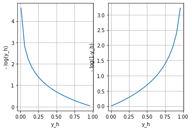

```python
import numpy as np
import matplotlib.pyplot as plt

y_h = np.arange(0.01, 1, 0.05)

plt.subplot(121)
plt.plot(y_h, -np.log(y_h))
plt.xlabel('y_h')
plt.ylabel('- log(y_h)')
plt.grid(True)

plt.subplot(122)
plt.plot(y_h, -np.log(1-y_h))
plt.xlabel('y_h')
plt.ylabel('- log(1-y_h)')
plt.grid(True)

plt.show()
```

### 경사하강(Gradient descent)

단일 훈련자료에 대한 로지스틱 회귀 **예측 모델**은 다음과 같이 정의 되고

$\hat{y}^{(i)} = \sigma(w^T x^{(i)} + b) \quad $ 여기에서 $\quad \sigma(z^{(i)}) = { 1 \over 1 + e^{-z^{(i)}} }$

전체 훈련 세트의 **손실함수**의 평균인 **비용함수**는 다음과 같다. $$ J(w, b) = { 1 \over m} \sum_{i=1}^m \mathscr{L} (\hat{y}^{(i)}, y^{(i)}) = -{ 1 \over m} \sum_{i=1}^m \left[ y^{(i)} \log (\hat{y}^{(i)}) + (1-y^{(i)}) \log (1-\hat{y}^{(i)}) \right] $$

여기에서, $ J(w, b)$ 를 최소화하는 매개 변수 $w$ 와 $b$ 을 찾을 것입니다.

[figure not shown]

### 경사하강 (Gradient descent)

[figure not shown]

## 미분(Derivatives) : 직관

[figure not shown]

## 미분(Derivatives) : 직관

[figure not shown]

## 미분(Derivatives) : 다양한 예

[figure not shown]

### 계산 그래프(Computation Graph)

$ J(a,b,c) = 3 ( a + bc) $

[figure not shown]

### 미분 계산(Computing Derivatives)

[figure not shown]

### 미분 계산(Computing Derivatives)

[figure not shown]

### Logistic Regression - Gradient Descent

$ z = w^T x + b$

$ \hat{y} = a = \sigma (z) $

$ \mathscr{L}(a, y) = - [y \log(a) + (1-y)\log(1-a)] $

[figure not shown]

### 로지스틱 회귀 미분

[figure not shown]

### m개의 훈련 자료에 대한 경사하강

$$ J(w, b) = { 1 \over m} \sum_{i=1}^m \mathscr{L} (a^{(i)}, y^{(i)}) $$

여기에서 $$ a^{(i)} = \hat{y}^{(i)} = \sigma(w^T x^{(i)}+ b) $$

$$ {\partial \over \partial w_1} J(w, b) = { 1 \over m} \sum_{i=1}^m {\partial \over \partial w_1} \mathscr{L} (a^{(i)}, y^{(i)})$$

다음과 같이 약식으로, $$ {\partial \over \partial w_1} \mathscr{L} (a^{(i)}, y^{(i)}) \Rightarrow dw_1^{(i)} \text{ of } ( x^{(i)}, y^{(i)}) $$

### m개의 훈련 자료에 대한 경사하강 : 구현

```
J = dw1 = dw2 = db = 0;

for i=1 to m:
    z(i) = w_T*x(i) + b
    a(i) = sigmoid(z)
    J += - (y(i)*log(a(i)) + (1-y(i))*log(1-a(i)))
    dz(i) = a(i) - y(i)
    dw1 += x1(i)*dz(i)
    dw2 += x2(i)*dz(i)
    db += dz(i)

J /= m
dw1 /= m; dw2 /= m; db /=m;
```

### 벡터화(Vectorization) : 벡터화란?

[figure not shown]

```python
import numpy as np

a = np.array([1,2,3,4])
a.shape
```

```
(4,)
```

```python
import time

a = np.random.rand(1000000)
b = np.random.rand(1000000)
print(a.shape, b.shape)

tic = time.time()
c = np.dot(a,b)
toc = time.time()

print("c = ", c)
print("Vectorization : ", str(1000*(toc-tic)), 'ms')

c = 0
tic = time.time()
for i in range(1000000):
    c += a[i]*b[i]
toc = time.time()

print("c = ", c)
print("For loop : ", str(1000*(toc-tic)), 'ms')
```

```
(1000000,) (1000000,)
c =  249602.10647531383
Vectorization :  1.0037422180175781 ms
c =  249602.10647531936
For loop :  1133.3503723144531 ms
```

### 벡터화(Vectorization) : 신경망 프로그래밍 지침

가능하면 명시적인 for 루프를 피하십시오.

[figure not shown]

### 벡터 및 행렬의 함수

행렬/벡터의 모든 요소에 지수 연산을 적용해야 한다고 가정해 보겠습니다.

$ v = \begin{bmatrix} v_1 \\ v_2 \\ \vdots \\ v_n \end{bmatrix} \quad \Rightarrow \quad u = \begin{bmatrix} e^{v_1} \\ e^{v_2} \\ \vdots \\ e^{v_n} \end{bmatrix}$

```
# For loop version ============
u = np.zeros((n,1))
for i in range(n):
    u[i] = math.exp(v[i])
```

### 로지스틱 회귀 미분 : 구현

[output not shown]

```
J = J/m, dw_1 = dw_1/m; dw_2 = dw_2/m
db = db/m;
```

## 로지스틱 회귀 벡터화

$$ z^{(1)} = w^T x^{(1)} + b \quad \quad \quad z^{(2)} = w^T x^{(2)} + b \quad \quad \quad z^{(3)} = w^T x^{(3)} + b $$$$ a^{(1)} = \sigma(z^{(1)})\quad \quad \quad \quad \quad a^{(2)} = \sigma(z^{(2)})\quad \quad \quad \quad a^{(3)} = \sigma(z^{(3)})$$

[figure not shown]

## 로지스틱 회귀 그래디언트 계산 벡터화

[figure not shown]

## 로지스틱 회귀 그래디언트 계산 벡터화 : 구현

[figure not shown]

## Broadcasting

(m,1) + (1,) ~> (m, 1)

$$ \begin{bmatrix} 1 \\ 2 \\ 3 \\ 4 \end{bmatrix} + 100 \quad \Rightarrow \quad \begin{bmatrix} 1 \\ 2 \\ 3 \\ 4 \end{bmatrix} + \begin{bmatrix} 100 \\ 100 \\ 100 \\ 100 \end{bmatrix}$$

(m, n) + (1, n) ~> (m, n)

$$ \begin{bmatrix} 1, 2, 3 \\ 4, 5, 6 \end{bmatrix} + \begin{bmatrix} 100, 200, 300 \end{bmatrix} \quad \Rightarrow \quad \begin{bmatrix} 1, 2, 3 \\ 4, 5, 6 \end{bmatrix} + \begin{bmatrix} 100, 200, 300 \\ 100, 200, 300 \end{bmatrix}$$

(m, n) + (m, 1) ~> (m, n)

$$ \begin{bmatrix} 1, 2, 3 \\ 4, 5, 6 \end{bmatrix} + \begin{bmatrix} 100 \\ 200 \end{bmatrix} \quad \Rightarrow \quad \begin{bmatrix} 1, 2, 3 \\ 4, 5, 6 \end{bmatrix} + \begin{bmatrix} 100, 100, 100 \\ 200, 200, 200 \end{bmatrix}$$

```python
import numpy as np

a = np.array([1,2,3,4])
# a = np.array([[1],[2],[3],[4]])
print(a, " + 100 = ", a+100)

b = np.array([[1,2,3],[4,5,6]])
c = np.array([100,200,300])
print(b.shape, " + ", c.shape, " = ", (b+c).shape)
print(b + c)

d = np.array([[100],[200]])
print(b.shape, " + ", d.shape, " = ", (b+d).shape)
print(b + d)
```

```
[1 2 3 4]  + 100 =  [101 102 103 104]
(2, 3)  +  (3,)  =  (2, 3)
[[101 202 303]
 [104 205 306]]
(2, 3)  +  (2, 1)  =  (2, 3)
[[101 102 103]
 [204 205 206]]
```

### 브로드케스팅 일반 원칙

[figure not shown]

(Example) 100g의 다양한 음식에 포함된 탄수화물, 단백질, 지방의 칼로리가 다음과 같을 때,탄수화물, 단백질, 지방으로부터의 칼로리가 각각 몇 % 인지를 계산하는 문제가 있다.

| \ | Apples | Beef | Eggs | Potatoes |
| --- | --- | --- | --- | --- |
| Carb | 56.0 | 0.0 | 4.4 | 68.0 |
| Protein | 1.2 | 104.0 | 52.0 | 8.0 |
| Fat | 1.8 | 135.0 | 99.0 | 0.9 |

위의 계산을 명시적인 for-loop 를 사용하지 않고 할 수 있는가?

```python
import numpy as np

A = np.array([[56.0, 0.0, 4.4, 68.0],
              [1.2, 104.0, 52.0, 8.0],
              [1.8, 135.0, 99.0, 0.9]])

cal = A.sum(axis = 0)
print(cal)
percentage = 100 * A / cal
print(percentage)
print(A.shape, cal.shape, percentage.shape)
```

```
[ 59.  239.  155.4  76.9]
[[94.91525424  0.          2.83140283 88.42652796]
 [ 2.03389831 43.51464435 33.46203346 10.40312094]
 [ 3.05084746 56.48535565 63.70656371  1.17035111]]
(3, 4) (4,) (3, 4)
```

## (선택 사항) 로지스틱 회귀 비용함수 설명

### 로지스틱 회귀 비용함수

로지스틱 회귀에서 주어진 $x$ 에 대한 추정 $\hat{y}$는 다음과 같이 계산됩니다. $$ \hat{y} = \sigma (w^T x + b) \quad\text{where}\quad \sigma(z) = { 1 \over 1 + e^{-z}}$$

그리고, 이는 $x$에 대하여 $y=1$일 확률, 즉, $ \hat{y} = P(y=1|x)$ 로 해석한다고 했습니다. 궁극적으로 우리의 알고리즘은 $ \hat{y}$ 이 입력 값 x에 대해서 **$y$가 1일 확률**을 나타내주길 바랍니다.

다시 말해, $y$가 1인 경우, 주어진 x에 대한 $y$ 일 확률이 $\hat{y}$이라고 할 수 있습니다. 반대로, 만약 $y$가 0 이면, $y$가 0일 확률은 $1- \hat{y}$이 됩니다. 따라서 $\hat{y}$ 은 $y$가 1일 확률이고, $1- \hat{y}$ 은 $y$가 0일 확률이 됩니다.

- $y=1$ 일 때는, $P(y|x) = \hat{y}$
- $y=0$ 일 때는, $P(y|x) = 1- \hat{y}$

### 로지스틱 회귀 비용함수

- $y=1$ 일 때는, $P(y|x) = \hat{y}$
- $y=0$ 일 때는, $P(y|x) = 1- \hat{y}$

위의 두 식을, 하나의 식으로 요약해보면 다음과 같이 됩니다.

$$ P(y|x) = \hat{y}^y (1-\hat{y})^{(1-y)}$$

- $y=1$ 일 때는, $P(y|x) = \hat{y}^1 (1- \hat{y})^0 = \hat{y}$
- $y=0$ 일 때는, $P(y|x) = \hat{y}^0 (1- \hat{y})^{1} = 1- \hat{y}$

$$ \begin{eqnarray} \log P(y|x) & = &\log \hat{y}^y (1-\hat{y})^{(1-y)} \\ & = &y \log \hat{y} + (1-y) \log (1-\hat{y}) \\ & = &- \mathscr{L}(\hat{y},y) \end{eqnarray}$$

### m 예제에 대한 비용

$$ P(\text{labels in training set}) = \log \prod_{i=1}^M P(y^{(i)} | x^{(i)})$$

최우추정 (Maximum Likelihood Estimation) :

$$ P(\text{labels in training set}) = \sum_{i=1}^M P(y^{(i)} | x^{(i)}) = - \sum_{i=1}^M \mathscr{L}(y^{(i)},y^{(i)})$$

Cost to minimize :

$$ J(w, b) = { 1 \over m} \sum_{i=1}^m \mathscr{L} (\hat{y}^{(i)}, y^{(i)}) $$